# Estudio Geoespacial de la Producción Agrícola por Pisos Altitudinales en el Perú

### Limpieza y Conversión Numérica en Arrow C++

Procesamos el casteo numérico y las validaciones de nulos directamente en la capa de Arrow para optimizar el rendimiento y evitar problemas de compatibilidad SQL:

```r
ds_clean <- ds_sel %>%
  mutate(
    # Limpieza y conversión de la Altitud (msnm)
    altitud_trim = str_trim(ALTITUD),
    altitud_clean = if_else(altitud_trim == "" | altitud_trim == " " | altitud_trim == "NA", NA_character_, altitud_trim),
    ALTITUD_num = cast(altitud_clean, float64()),

    # Limpieza y conversión del Factor de expansión muestral
    factor_trim = str_trim(FACTOR),
    factor_clean = if_else(factor_trim == "" | factor_trim == " " | factor_trim == "NA", NA_character_, factor_trim),
    FACTOR_num = cast(factor_clean, float64()),

    # Cantidad entera
    cant_ent_trim = str_trim(P420_CANT_ENT),
    cant_ent_clean = if_else(cant_ent_trim == "" | cant_ent_trim == " " | cant_ent_trim == "NA", NA_character_, cant_ent_trim),
    P420_CANT_ENT_num = cast(cant_ent_clean, float64()),

    # Cantidad decimal
    cant_dec_trim = str_trim(P420_CANT_DEC),
    cant_dec_clean = if_else(cant_dec_trim == "" | cant_dec_trim == " " | cant_dec_trim == "NA", NA_character_, cant_dec_trim),
    P420_CANT_DEC_num = cast(cant_dec_clean, float64()),

    # Equivalencia en Kilogramos
    equiv_trim = str_trim(P420_EQUIV),
    equiv_trim = if_else(str_starts(equiv_trim, "."), paste0("0", equiv_trim), equiv_trim),
    equiv_clean = if_else(equiv_trim == "" | equiv_trim == " " | equiv_trim == "NA", NA_character_, equiv_trim),
    P420_EQUIV_num = cast(equiv_clean, float64())
  ) %>%
  mutate(
    # Cálculo robusto de producción total ponderada en Kilogramos (evitamos nulos propagados)
    cantidad = coalesce(P420_CANT_ENT_num, 0) + (coalesce(P420_CANT_DEC_num, 0) / 100),
    kg_pond = cantidad * coalesce(P420_EQUIV_num, 1.0) * coalesce(FACTOR_num, 1.0)
  )
```

### Muestreo y Cálculo de Jenks (DuckDB)

Pasamos el flujo ya procesado a DuckDB para un muestreo rápido del **5%**:

```r
# Transferimos el dataset pre-procesado a DuckDB
ds_duckdb <- ds_clean %>% to_duckdb()

porcentaje_muestreo <- 0.05

# Extraemos la muestra representativa de altitudes en paralelo
altitudes_sample <- ds_duckdb %>%
  select(ALTITUD_num) %>%
  filter(!is.na(ALTITUD_num)) %>%
  filter(random() < porcentaje_muestreo) %>%
  collect() %>%
  pull(ALTITUD_num)

cat(sprintf("Muestra de altitudes descargada con éxito. Registros: %s\n", comma(length(altitudes_sample))))
```

```
## Muestra de altitudes descargada con éxito. Registros: 629
```

```r
# Ejecutamos el algoritmo de Cortes Naturales de Jenks para 8 clases
cortes <- classIntervals(altitudes_sample, n = 8, style = "jenks")
brks <- cortes$brks

cat("Límites de Jenks calculados:\n")
```

```
## Límites de Jenks calculados:
```

```r
print(brks)
```

```
## [1]    5  353  902 1701 2481 3071 3629 4156 5008
```

### Clasificación Robusta con Tidy Evaluation (`!!`)

Inyectamos los límites numéricos y etiquetas formateadas de R directamente en la consulta perezosa de DuckDB para garantizar inmunidad contra fallos de compilación:

```r
# 1. Asignamos cada límite a variables escalares de R
b1 <- as.numeric(brks[1])
b2 <- as.numeric(brks[2])
b3 <- as.numeric(brks[3])
b4 <- as.numeric(brks[4])
b5 <- as.numeric(brks[5])
b6 <- as.numeric(brks[6])
b7 <- as.numeric(brks[7])
b8 <- as.numeric(brks[8])
b9 <- as.numeric(brks[9])

# 2. Generamos las etiquetas de texto
lbl1 <- paste0("Piso 1 (", round(b1), "-", round(b2), " m)")
lbl2 <- paste0("Piso 2 (", round(b2), "-", round(b3), " m)")
lbl3 <- paste0("Piso 3 (", round(b3), "-", round(b4), " m)")
lbl4 <- paste0("Piso 4 (", round(b4), "-", round(b5), " m)")
lbl5 <- paste0("Piso 5 (", round(b5), "-", round(b6), " m)")
lbl6 <- paste0("Piso 6 (", round(b6), "-", round(b7), " m)")
lbl7 <- paste0("Piso 7 (", round(b7), "-", round(b8), " m)")
lbl8 <- paste0("Piso 8 (", round(b8), "-", round(b9), " m)")

# 3. Clasificación masiva e inmune inyectando los valores directos
ds_classified <- ds_duckdb %>%
  mutate(
    PISO_ALTITUDINAL = case_when(
      ALTITUD_num >= !!b1 & ALTITUD_num <= !!b2 ~ !!lbl1,
      ALTITUD_num > !!b2  & ALTITUD_num <= !!b3  ~ !!lbl2,
      ALTITUD_num > !!b3  & ALTITUD_num <= !!b4  ~ !!lbl3,
      ALTITUD_num > !!b4  & ALTITUD_num <= !!b5  ~ !!lbl4,
      ALTITUD_num > !!b5  & ALTITUD_num <= !!b6  ~ !!lbl5,
      ALTITUD_num > !!b6  & ALTITUD_num <= !!b7  ~ !!lbl6,
      ALTITUD_num > !!b7  & ALTITUD_num <= !!b8  ~ !!lbl7,
      ALTITUD_num > !!b8  & ALTITUD_num <= !!b9  ~ !!lbl8,
      TRUE ~ "Desconocido/NA"
    )
  )
```

### Agregación y Descarga (collect)

Realizamos la agregación masiva y cargamos únicamente el consolidado final a R:

```r
resumen_pisos <- ds_classified %>%
  group_by(PISO_ALTITUDINAL) %>%
  summarise(
    produccion_total_kg = sum(kg_pond, na.rm = TRUE),
    n_productores = n(),
    .groups = "drop"
  ) %>%
  collect()

# Convertimos de Kg a Toneladas (t) y ordenamos lógicamente los factores
resumen_pisos_clean <- resumen_pisos %>%
  filter(!is.na(PISO_ALTITUDINAL), PISO_ALTITUDINAL != "Desconocido/NA") %>%
  mutate(
    produccion_total_t = produccion_total_kg / 1000,
    piso_id = as.integer(gsub("Piso ([0-9]+).*", "\\1", PISO_ALTITUDINAL))
  ) %>%
  arrange(piso_id) %>%
  mutate(PISO_ALTITUDINAL = fct_inorder(PISO_ALTITUDINAL))

# Imprimimos los resultados agregados consolidados
knitr::kable(resumen_pisos_clean, caption = "Producción Agrícola Agregada por Piso Altitudinal")
```

Producción Agrícola Agregada por Piso Altitudinal

| PISO_ALTITUDINAL | produccion_total_kg | n_productores | produccion_total_t | piso_id |
| --- | --- | --- | --- | --- |
| Piso 1 (5-353 m) | 100461.569 | 3391 | 100.461569 | 1 |
| Piso 2 (353-902 m) | 172483.965 | 1300 | 172.483965 | 2 |
| Piso 3 (902-1701 m) | 9782.528 | 1004 | 9.782528 | 3 |
| Piso 4 (1701-2481 m) | 8418.974 | 1111 | 8.418974 | 4 |
| Piso 5 (2481-3071 m) | 320814.758 | 1283 | 320.814758 | 5 |
| Piso 6 (3071-3629 m) | 242752.296 | 1909 | 242.752296 | 6 |
| Piso 7 (3629-4156 m) | 494065.556 | 1833 | 494.065557 | 7 |
| Piso 8 (4156-5008 m) | 248876.580 | 972 | 248.876580 | 8 |

# 4. Visualización de los Resultados Académicos

Generamos el gráfico de barras final de calidad científica con `ggplot2`:

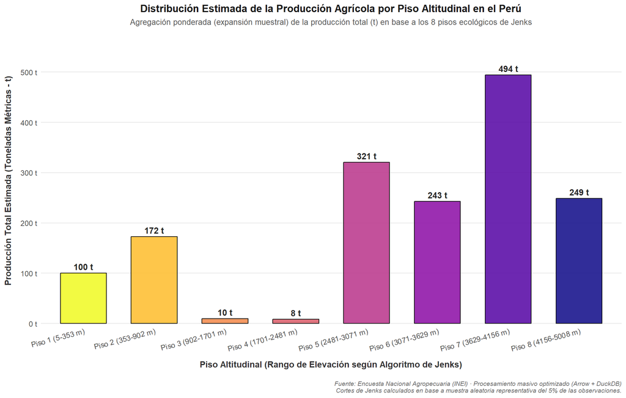

```r
ggplot(resumen_pisos_clean, aes(x = PISO_ALTITUDINAL, y = produccion_total_t, fill = PISO_ALTITUDINAL)) +
  # Renderizado de barras con bordes estilizados
  geom_col(color = "black", width = 0.65, alpha = 0.85, show.legend = FALSE) +
  # Etiquetas numéricas sobre las columnas
  geom_text(
    aes(label = sprintf("%s t", comma(produccion_total_t, accuracy = 1))),
    vjust = -0.5,
    fontface = "bold",
    size = 3.8,
    color = "grey15"
  ) +
  # Paleta de color académica de alto contraste (Plasma)
  scale_fill_viridis_d(option = "plasma", direction = -1) +
  # Eje Y con etiquetas bien formateadas en toneladas
  scale_y_continuous(
    labels = comma_format(suffix = " t"),
    expand = expansion(mult = c(0, 0.15))
  ) +
  # Configuración del diseño minimalista
  theme_minimal(base_family = "sans", base_size = 11) +
  theme(
    plot.title = element_text(face = "bold", size = 13, color = "grey10", hjust = 0.5),
    plot.subtitle = element_text(size = 10, color = "grey35", hjust = 0.5, margin = margin(b = 15)),
    plot.caption = element_text(size = 8, face = "italic", color = "grey40", margin = margin(t = 15)),
    axis.title.x = element_text(face = "bold", color = "grey20", margin = margin(t = 10)),
    axis.title.y = element_text(face = "bold", color = "grey20", margin = margin(r = 10)),
    axis.text = element_text(color = "grey30", size = 9.5),
    axis.text.x = element_text(angle = 15, hjust = 1),
    panel.grid.major.x = element_blank(),
    panel.grid.minor = element_blank(),
    panel.grid.major.y = element_line(color = "grey90", linewidth = 0.5)
  ) +
  labs(
    title = "Distribución Estimada de la Producción Agrícola por Piso Altitudinal en el Perú",
    subtitle = "Agregación ponderada (expansión muestral) de la producción total (t) en base a los 8 pisos ecológicos de Jenks",
    x = "Piso Altitudinal (Rango de Elevación según Algoritmo de Jenks)",
    y = "Producción Total Estimada (Toneladas Métricas - t)",
    caption = sprintf("Fuente: Encuesta Nacional Agropecuaria (INEI) · Procesamiento masivo optimizado (Arrow + DuckDB)\nCortes de Jenks calculados en base a muestra aleatoria representativa del %.0f%% de las observaciones.", porcentaje_muestreo * 100)
  )
```